# DATA621_Home_Work_3

Dilip Ganesan

6/28/2018

## Home Work Assignment 3.

## 1.DATA EXPLORATION.(Exploratory Data Analysis EDA)

As first step in our EDA, let us load the train data and do a summary statistics on the loaded dataset.

```r
# Let us load the train.csv data
train = read.csv('crime-training-data.csv')
test = read.csv('crime-evaluation-data.csv')

summary(train)
```

```
##        zn             indus             chas              nox
##  Min.   :  0.00   Min.   : 0.460   Min.   :0.00000   Min.   :0.3890
##  1st Qu.:  0.00   1st Qu.: 5.145   1st Qu.:0.00000   1st Qu.:0.4480
##  Median :  0.00   Median : 9.690   Median :0.00000   Median :0.5380
##  Mean   : 11.58   Mean   :11.105   Mean   :0.07082   Mean   :0.5543
##  3rd Qu.: 16.25   3rd Qu.:18.100   3rd Qu.:0.00000   3rd Qu.:0.6240
##  Max.   :100.00   Max.   :27.740   Max.   :1.00000   Max.   :0.8710
##        rm             age              dis              rad
##  Min.   :3.863   Min.   :  2.90   Min.   : 1.130   Min.   : 1.00
##  1st Qu.:5.887   1st Qu.: 43.88   1st Qu.: 2.101   1st Qu.: 4.00
##  Median :6.210   Median : 77.15   Median : 3.191   Median : 5.00
##  Mean   :6.291   Mean   : 68.37   Mean   : 3.796   Mean   : 9.53
##  3rd Qu.:6.630   3rd Qu.: 94.10   3rd Qu.: 5.215   3rd Qu.:24.00
##  Max.   :8.780   Max.   :100.00   Max.   :12.127   Max.   :24.00
##       tax           ptratio         black            lstat
##  Min.   :187.0   Min.   :12.6   Min.   :  0.32   Min.   : 1.730
##  1st Qu.:281.0   1st Qu.:16.9   1st Qu.:375.61   1st Qu.: 7.043
##  Median :334.5   Median :18.9   Median :391.34   Median :11.350
##  Mean   :409.5   Mean   :18.4   Mean   :357.12   Mean   :12.631
##  3rd Qu.:666.0   3rd Qu.:20.2   3rd Qu.:396.24   3rd Qu.:16.930
##  Max.   :711.0   Max.   :22.0   Max.   :396.90   Max.   :37.970
##       medv           target
##  Min.   : 5.00   Min.   :0.0000
##  1st Qu.:17.02   1st Qu.:0.0000
##  Median :21.20   Median :0.0000
##  Mean   :22.59   Mean   :0.4914
##  3rd Qu.:25.00   3rd Qu.:1.0000
##  Max.   :50.00   Max.   :1.0000
```

We will make sure there is no inappropriate distribution of target(response) variables in our training data.

```r
knitr::kable(table(train$target))
```

| Var1 | Freq |
| --- | --- |
| 0 | 237 |
| 1 | 229 |

## Examination of Data Set.

1. There are 466 rows and 14 columns in the train data set. Out of 14 columns, 12 are continous variables and 2 are discrete variables. There are no NA values in the dataset.
2. On exploring the train data set,we see 13 predictor variables. All the variables are related to housing ranging from ethinicity, age group, income level to how big the houses are, number of square feet that is owned.
3. For the binary logistic regression, the variable target is the response variables, with value of 0 or 1. 1 indicates crime rate is above the median value.
4. On a general glance one might think of following variables be positively correlated with higher crime rate.Like lstat, indus, nox, ptratio etc. Similarly following variabls as negatively correlated with higher crime rates. Like zn, rm, rad, medv.

## Statistical Summary of Data Set:

```r
summary = describe(train, quant = c(.25,.75))
knitr::kable(summary)
```

|  | vars | n | mean | sd | median | trimmed | mad | min | max | range | skew | kurtosis | se | Q0.25 | Q0.75 |
| --- | --- | --- | --- | --- | --- | --- | --- | --- | --- | --- | --- | --- | --- | --- | --- |
| zn | 1 | 466 | 11.5772532 | 23.3646511 | 0.00000 | 5.3542781 | 0.0000000 | 0.0000 | 100.0000 | 100.0000 | 2.1768152 | 3.8135765 | 1.0823466 | 0.000000 | 16.25000 |
| indus | 2 | 466 | 11.1050215 | 6.8458549 | 9.69000 | 10.9082353 | 9.3403800 | 0.4600 | 27.7400 | 27.2800 | 0.2885450 | -1.2432132 | 0.3171281 | 5.145000 | 18.10000 |
| chas | 3 | 466 | 0.0708155 | 0.2567920 | 0.00000 | 0.0000000 | 0.0000000 | 0.0000 | 1.0000 | 1.0000 | 3.3354899 | 9.1451313 | 0.0118957 | 0.000000 | 0.00000 |
| nox | 4 | 466 | 0.5543105 | 0.1166667 | 0.53800 | 0.5442684 | 0.1334340 | 0.3890 | 0.8710 | 0.4820 | 0.7463281 | -0.0357736 | 0.0054045 | 0.448000 | 0.62400 |
| rm | 5 | 466 | 6.2906738 | 0.7048513 | 6.21000 | 6.2570615 | 0.5166861 | 3.8630 | 8.7800 | 4.9170 | 0.4793202 | 1.5424378 | 0.0326516 | 5.887250 | 6.62975 |
| age | 6 | 466 | 68.3675966 | 28.3213784 | 77.15000 | 70.9553476 | 30.0226500 | 2.9000 | 100.0000 | 97.1000 | -0.5777075 | -1.0098814 | 1.3119625 | 43.875000 | 94.10000 |
| dis | 7 | 466 | 3.7956929 | 2.1069496 | 3.19095 | 3.5443647 | 1.9144814 | 1.1296 | 12.1265 | 10.9969 | 0.9988926 | 0.4719679 | 0.0976026 | 2.101425 | 5.21460 |
| rad | 8 | 466 | 9.5300429 | 8.6859272 | 5.00000 | 8.6978610 | 1.4826000 | 1.0000 | 24.0000 | 23.0000 | 1.0102788 | -0.8619110 | 0.4023678 | 4.000000 | 24.00000 |
| tax | 9 | 466 | 409.5021459 | 167.9000887 | 334.50000 | 401.5080214 | 104.5233000 | 187.0000 | 711.0000 | 524.0000 | 0.6593136 | -1.1480456 | 7.7778214 | 281.000000 | 666.00000 |
| ptratio | 10 | 466 | 18.3984979 | 2.1968447 | 18.90000 | 18.5970588 | 1.9273800 | 12.6000 | 22.0000 | 9.4000 | -0.7542681 | -0.4003627 | 0.1017669 | 16.900000 | 20.20000 |
| black | 11 | 466 | 357.1201502 | 91.3211298 | 391.34000 | 383.5064439 | 8.2432560 | 0.3200 | 396.9000 | 396.5800 | -2.9163108 | 7.3419310 | 4.2303696 | 375.607500 | 396.23750 |
| lstat | 12 | 466 | 12.6314592 | 7.1018907 | 11.35000 | 11.8809626 | 7.0720020 | 1.7300 | 37.9700 | 36.2400 | 0.9055864 | 0.5033688 | 0.3289887 | 7.042500 | 16.93000 |
| medv | 13 | 466 | 22.5892704 | 9.2396814 | 21.20000 | 21.6304813 | 6.0045300 | 5.0000 | 50.0000 | 45.0000 | 1.0766920 | 1.3737825 | 0.4280200 | 17.025000 | 25.00000 |
| target | 14 | 466 | 0.4914163 | 0.5004636 | 0.00000 | 0.4893048 | 0.0000000 | 0.0000 | 1.0000 | 1.0000 | 0.0342293 | -2.0031131 | 0.0231835 | 0.000000 | 1.00000 |

## Visual Exploration of Data set:

*Scatterplot*

1. First we will see the scatterplot between the predictor variables and response variables.

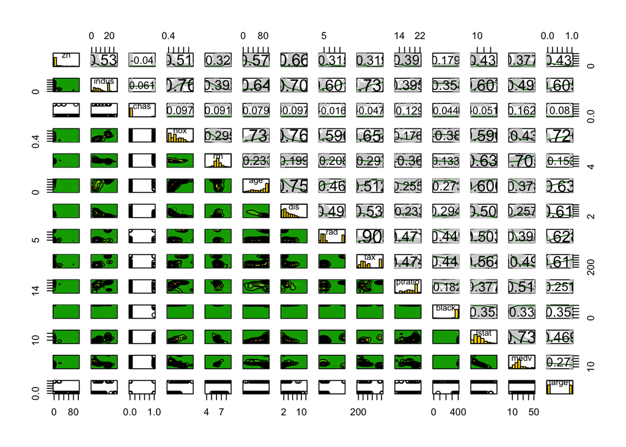

```r
kdepairs(train)
```

From the scatterplot, several of the predictor variables has non linear relationship with each other.

*Histogram*

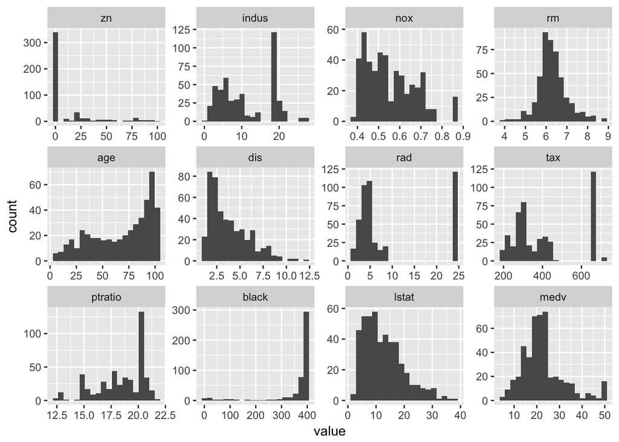

```r
ggtrain = reshape::melt(train, id.vars = "target") %>%
  dplyr::filter(variable != "chas") %>%
  mutate(target = as.factor(target))

ggplot(data = ggtrain, aes(value)) +
  geom_histogram(bins = 20) +
  facet_wrap(~variable, scales = "free")
```

1. From the histogram we can see that variable Zn is skewed. This is a ideal candidate for transformation.
2. To some extent even the variables dis, age and lstat are skewed. So we can think of doing some transformation on these variables.

*MultiCollinearity between predictor variables and also with response variables*

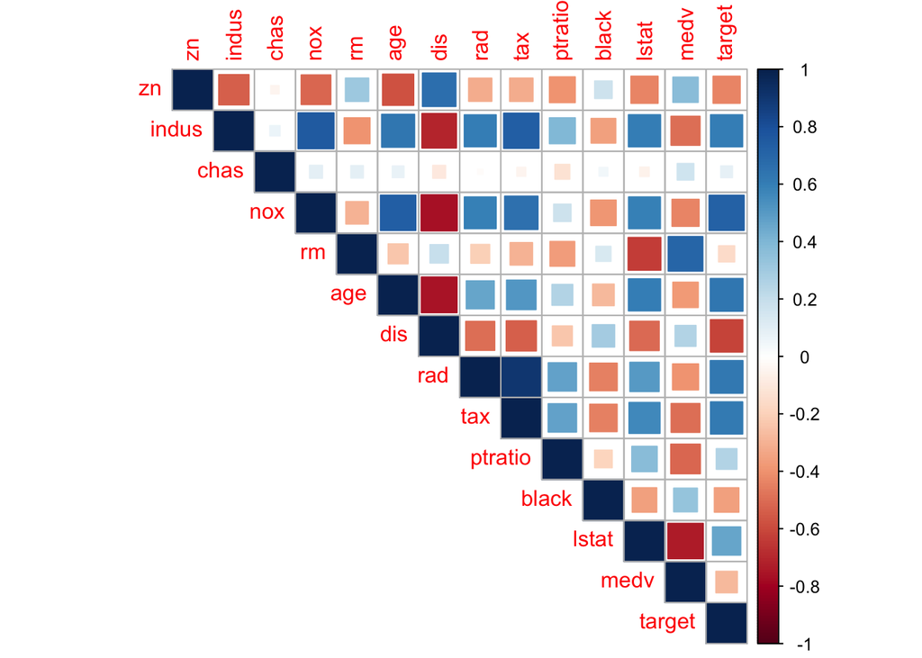

```r
cordata = cor(train)
corrplot(cordata, method = "square", type = "upper")
```

From the corrplot we can see that tax and rad has a high positive correlation. In our model we have to remove multicollinearity by checking the varaiance inflation factor.

With respect to response and predictor variables, the variable nox has highest correlation with response variable. We have to see how this affect our modelling.

## 2.DATA PREPARATION

From our visual exploration we have identified few variables to go through transformation based on the dataset.

```r
train_data_transform =
  train %>%
  mutate(
    log_age = log(age),
    log_lstat = log(lstat))
```

## 3. BUILDING MODELS

As approach we are going to build the following models.

Each of our logistic regression models will use bionomial regression with a logit link function

1. Using the data set asis with 13 predictor variables and 1 response variable. This model we will call it the Base Model with all original variables in data set.

*Base Model*

```r
base_model = glm(target ~ . , family = "binomial", data = train)
summary(base_model)
```

```
##
## Call:
## glm(formula = target ~ ., family = "binomial", data = train)
##
## Deviance Residuals:
##     Min       1Q   Median       3Q      Max
## -2.2854  -0.1372  -0.0017   0.0020   3.4721
##
## Coefficients:
##               Estimate Std. Error z value Pr(>|z|)
## (Intercept) -36.839521   7.028726  -5.241 1.59e-07 ***
## zn           -0.061720   0.034410  -1.794 0.072868 .
## indus        -0.072580   0.048546  -1.495 0.134894
## chas          1.032352   0.759627   1.359 0.174139
## nox          50.159513   8.049503   6.231 4.62e-10 ***
## rm           -0.692145   0.741431  -0.934 0.350548
## age           0.034522   0.013883   2.487 0.012895 *
## dis           0.765795   0.234407   3.267 0.001087 **
## rad           0.663015   0.165135   4.015 5.94e-05 ***
## tax          -0.006593   0.003064  -2.152 0.031422 *
## ptratio       0.442217   0.132234   3.344 0.000825 ***
## black        -0.013094   0.006680  -1.960 0.049974 *
## lstat         0.047571   0.054508   0.873 0.382802
## medv          0.199734   0.071022   2.812 0.004919 **
## ---
## Signif. codes:  0 '***' 0.001 '**' 0.01 '*' 0.05 '.' 0.1 ' ' 1
##
## (Dispersion parameter for binomial family taken to be 1)
##
##     Null deviance: 645.88  on 465  degrees of freedom
## Residual deviance: 186.15  on 452  degrees of freedom
## AIC: 214.15
##
## Number of Fisher Scoring iterations: 9
```

```r
knitr::kable(vif(base_model))
```

|  | x |
| --- | --- |
| zn | 1.846737 |
| indus | 2.699928 |
| chas | 1.262505 |
| nox | 4.296876 |
| rm | 6.070541 |
| age | 2.556302 |
| dis | 4.025192 |
| rad | 1.955112 |
| tax | 2.174569 |
| ptratio | 2.340600 |
| black | 1.091380 |
| lstat | 2.681384 |
| medv | 8.567935 |

```r
hoslem.test(train$target, fitted(base_model))
```

```
##
##  Hosmer and Lemeshow goodness of fit (GOF) test
##
## data:  train$target, fitted(base_model)
## X-squared = 18.284, df = 8, p-value = 0.01919
```

```r
rocBasePlot = roc(base_model$y, fitted(base_model))
AUC = as.numeric(pROC::roc(base_model$y, fitted(base_model))$auc)
AUC
```

```
## [1] 0.9752732
```

*Observations*

From the above model, we see 5 out of the 13 variables has (stat-sig) p-values at a significance level greater than 0.05

The coefficient for nox has the highest, which has the highest positive correlation with response variables.

From the VIF function we can see that the following variables has VIF > 4. medv, dis, rm, nox. In our next model we can think of eliminating these as part of Multicollinearity test.

*Base Model and Transformed Variables*

```r
base_transform_model = glm(target ~ . , family = "binomial", data = train_data_transform)
summary(base_transform_model)
```

```
##
## Call:
## glm(formula = target ~ ., family = "binomial", data = train_data_transform)
##
## Deviance Residuals:
##     Min       1Q   Median       3Q      Max
## -2.1248  -0.1192  -0.0011   0.0011   3.6868
##
## Coefficients:
##               Estimate Std. Error z value Pr(>|z|)
## (Intercept) -23.635217   7.571815  -3.121 0.001799 **
## zn           -0.055881   0.035993  -1.553 0.120526
## indus        -0.101194   0.052445  -1.930 0.053663 .
## chas          1.122399   0.801642   1.400 0.161476
## nox          54.328789   8.623808   6.300 2.98e-10 ***
## rm           -1.359041   0.810076  -1.678 0.093411 .
## age           0.100905   0.029182   3.458 0.000545 ***
## dis           0.697220   0.246068   2.833 0.004605 **
## rad           0.752047   0.180006   4.178 2.94e-05 ***
## tax          -0.008355   0.003422  -2.441 0.014631 *
## ptratio       0.481006   0.137144   3.507 0.000453 ***
## black        -0.012212   0.006326  -1.931 0.053531 .
## lstat         0.146375   0.126348   1.159 0.246656
## medv          0.197820   0.076160   2.597 0.009392 **
## log_age      -3.089161   1.100215  -2.808 0.004988 **
## log_lstat    -1.965229   1.628603  -1.207 0.227549
## ---
## Signif. codes:  0 '***' 0.001 '**' 0.01 '*' 0.05 '.' 0.1 ' ' 1
##
## (Dispersion parameter for binomial family taken to be 1)
##
##     Null deviance: 645.88  on 465  degrees of freedom
## Residual deviance: 177.34  on 450  degrees of freedom
## AIC: 209.34
##
## Number of Fisher Scoring iterations: 9
```

```r
knitr::kable(vif(base_transform_model))
```

|  | x |
| --- | --- |
| zn | 1.868586 |
| indus | 2.825736 |
| chas | 1.276773 |
| nox | 4.563620 |
| rm | 6.971836 |
| age | 13.126723 |
| dis | 4.094431 |
| rad | 2.203775 |
| tax | 2.414672 |
| ptratio | 2.321585 |
| black | 1.098637 |
| lstat | 14.347795 |
| medv | 9.217597 |
| log_age | 9.991509 |
| log_lstat | 18.646352 |

```r
hoslem.test(train$target, fitted(base_transform_model))
```

```
##
##  Hosmer and Lemeshow goodness of fit (GOF) test
##
## data:  train$target, fitted(base_transform_model)
## X-squared = 25.751, df = 8, p-value = 0.001159
```

```r
rocBaseTransformPlot = roc(base_transform_model$y, fitted(base_transform_model))
AUC = as.numeric(pROC::roc(base_transform_model$y, fitted(base_transform_model))$auc)
AUC
```

```
## [1] 0.9771157
```

*Observations*

From the AUC(Area under the curve) values above of ‘r AUC’ is relatively high at .977. This model is good at predicting the response variable.

Considering the confounding multicollinearity issue this model is creating, this will not be the ideal candidate.

*Base Model Backward Elimination*

3. For this model, we are going to use the Base Model and we are going to remove the variables which has higher p-value(>0.05).

The following variables have been removed from base_model variables. zn, indus, chas, rm, lstat

```r
train_new = subset(train, select = -c(zn, indus, chas, rm, lstat))

base_backward_model = glm(target ~ . , family = "binomial", data = train_new)
summary(base_backward_model)
```

```
##
## Call:
## glm(formula = target ~ ., family = "binomial", data = train_new)
##
## Deviance Residuals:
##      Min        1Q    Median        3Q       Max
## -2.42422  -0.19292  -0.01400   0.00279   3.06740
##
## Coefficients:
##               Estimate Std. Error z value Pr(>|z|)
## (Intercept) -32.301655   6.382694  -5.061 4.17e-07 ***
## nox          42.160350   6.674149   6.317 2.67e-10 ***
## age           0.031017   0.010681   2.904 0.003684 **
## dis           0.437803   0.172533   2.538 0.011165 *
## rad           0.703446   0.140296   5.014 5.33e-07 ***
## tax          -0.008744   0.002611  -3.348 0.000813 ***
## ptratio       0.395580   0.112482   3.517 0.000437 ***
## black        -0.012490   0.006760  -1.848 0.064662 .
## medv          0.101177   0.034116   2.966 0.003020 **
## ---
## Signif. codes:  0 '***' 0.001 '**' 0.01 '*' 0.05 '.' 0.1 ' ' 1
##
## (Dispersion parameter for binomial family taken to be 1)
##
##     Null deviance: 645.88  on 465  degrees of freedom
## Residual deviance: 198.28  on 457  degrees of freedom
## AIC: 216.28
##
## Number of Fisher Scoring iterations: 9
```

```r
knitr::kable(vif(base_backward_model))
```

|  | x |
| --- | --- |
| nox | 3.338245 |
| age | 1.726911 |
| dis | 2.800880 |
| rad | 1.646105 |
| tax | 1.706377 |
| ptratio | 1.703399 |
| black | 1.064837 |
| medv | 2.135365 |

```r
hoslem.test(train$target, fitted(base_backward_model))
```

```
##
##  Hosmer and Lemeshow goodness of fit (GOF) test
##
## data:  train$target, fitted(base_backward_model)
## X-squared = 2.3393, df = 8, p-value = 0.9688
```

```r
rocBaseBackwardPlot = roc(base_backward_model$y, fitted(base_backward_model))
AUC = as.numeric(pROC::roc(base_backward_model$y, fitted(base_backward_model))$auc)
AUC
```

```
## [1] 0.9712196
```

*Observations*

From the VIF function we can see 0 variables has VIF > 4.

From the AUC(Area under the curve) values above of ‘r AUC’ is relatively high at .971.

*Step Model*

4. For our final model, we will use the step function on the base model variables.

```r
base_step_model = step(base_model)
```

```
## Start:  AIC=214.15
## target ~ zn + indus + chas + nox + rm + age + dis + rad + tax +
##     ptratio + black + lstat + medv
##
##           Df Deviance    AIC
## - lstat    1   186.91 212.91
## - rm       1   187.03 213.03
## - chas     1   188.02 214.02
## <none>         186.15 214.15
## - indus    1   188.52 214.52
## - zn       1   190.49 216.49
## - tax      1   191.03 217.03
## - black    1   192.05 218.05
## - age      1   192.96 218.96
## - medv     1   195.29 221.29
## - dis      1   198.48 224.48
## - ptratio  1   198.76 224.76
## - rad      1   223.66 249.66
## - nox      1   257.46 283.46
##
## Step:  AIC=212.91
## target ~ zn + indus + chas + nox + rm + age + dis + rad + tax +
##     ptratio + black + medv
##
##           Df Deviance    AIC
## - rm       1   188.88 212.88
## <none>         186.91 212.91
## - indus    1   189.14 213.14
## - chas     1   189.17 213.17
## - zn       1   190.90 214.90
## - tax      1   191.41 215.41
## - black    1   192.77 216.77
## - medv     1   196.21 220.21
## - age      1   197.65 221.65
## - dis      1   199.62 223.62
## - ptratio  1   200.26 224.26
## - rad      1   224.12 248.12
## - nox      1   259.54 283.54
##
## Step:  AIC=212.88
## target ~ zn + indus + chas + nox + age + dis + rad + tax + ptratio +
##     black + medv
##
##           Df Deviance    AIC
## <none>         188.88 212.88
## - indus    1   190.94 212.94
## - chas     1   191.35 213.35
## - zn       1   193.34 215.34
## - tax      1   193.67 215.67
## - black    1   194.32 216.32
## - age      1   197.65 219.65
## - dis      1   200.09 222.09
## - ptratio  1   200.29 222.29
## - medv     1   201.97 223.97
## - rad      1   225.37 247.37
## - nox      1   259.83 281.83
```

```r
summary(base_step_model)
```

```
##
## Call:
## glm(formula = target ~ zn + indus + chas + nox + age + dis +
##     rad + tax + ptratio + black + medv, family = "binomial",
##     data = train)
##
## Deviance Residuals:
##     Min       1Q   Median       3Q      Max
## -2.4411  -0.1739  -0.0026   0.0030   3.4506
##
## Coefficients:
##               Estimate Std. Error z value Pr(>|z|)
## (Intercept) -36.364060   6.862463  -5.299 1.16e-07 ***
## zn           -0.059091   0.032498  -1.818 0.069016 .
## indus        -0.067194   0.048295  -1.391 0.164128
## chas          1.217987   0.777917   1.566 0.117418
## nox          48.468529   7.790233   6.222 4.92e-10 ***
## age           0.031961   0.011164   2.863 0.004197 **
## dis           0.703484   0.220707   3.187 0.001436 **
## rad           0.620491   0.156587   3.963 7.41e-05 ***
## tax          -0.006392   0.003012  -2.122 0.033812 *
## ptratio       0.385927   0.118437   3.258 0.001120 **
## black        -0.012935   0.006940  -1.864 0.062342 .
## medv          0.119666   0.035873   3.336 0.000851 ***
## ---
## Signif. codes:  0 '***' 0.001 '**' 0.01 '*' 0.05 '.' 0.1 ' ' 1
##
## (Dispersion parameter for binomial family taken to be 1)
##
##     Null deviance: 645.88  on 465  degrees of freedom
## Residual deviance: 188.88  on 454  degrees of freedom
## AIC: 212.88
##
## Number of Fisher Scoring iterations: 9
```

```r
knitr::kable(vif(base_step_model))
```

|  | x |
| --- | --- |
| zn | 1.753036 |
| indus | 2.659125 |
| chas | 1.204903 |
| nox | 4.080484 |
| age | 1.708242 |
| dis | 3.614058 |
| rad | 1.806566 |
| tax | 2.090838 |
| ptratio | 1.902591 |
| black | 1.082317 |
| medv | 2.248962 |

```r
hoslem.test(train$target, fitted(base_step_model))
```

```
##
##  Hosmer and Lemeshow goodness of fit (GOF) test
##
## data:  train$target, fitted(base_step_model)
## X-squared = 14.842, df = 8, p-value = 0.06228
```

```r
rocBaseStepPlot = roc(base_step_model$y, fitted(base_step_model))
AUC = as.numeric(pROC::roc(base_step_model$y, fitted(base_step_model))$auc)
AUC
```

```
## [1] 0.9746467
```

*Observations*

From the VIF function we can see that the following variables has VIF > 4. nox.

From the above Hoslem test we can see the value of p = 0.06228, which is little more than 0.05. Which says our model is pretty good.

From the AUC(Area under the curve) values above of ‘r AUC’ is relatively high at .974. This model is good at predicting the response variable.

## 4. MODEL SELECTION:

From our 4 Model, we will first see the ROC and AUC curve.

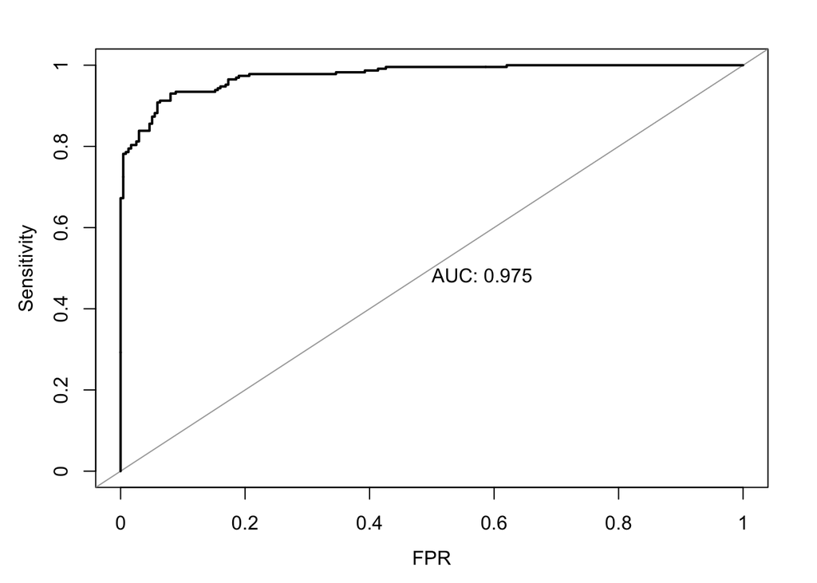

```r
plot(rocBasePlot, asp=NA, legacy.axes = TRUE, print.auc=TRUE, xlab="FPR")
```

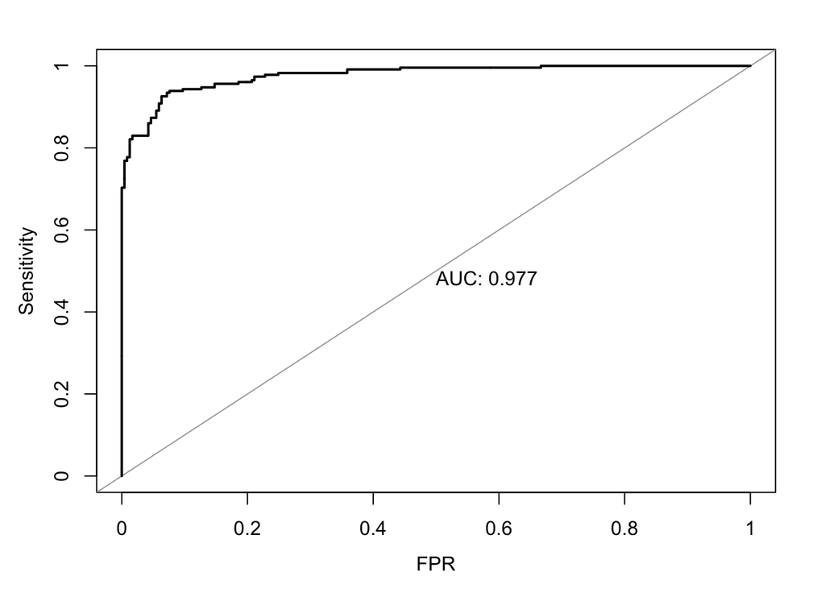

```r
plot(rocBaseTransformPlot, asp=NA, legacy.axes = TRUE, print.auc=TRUE, xlab="FPR")
```

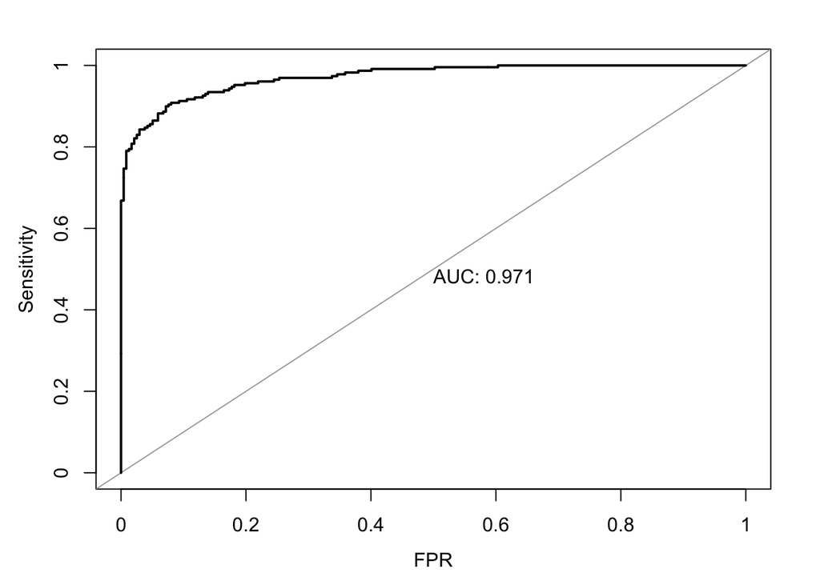

```r
plot(rocBaseBackwardPlot, asp=NA, legacy.axes = TRUE, print.auc=TRUE, xlab="FPR")
```

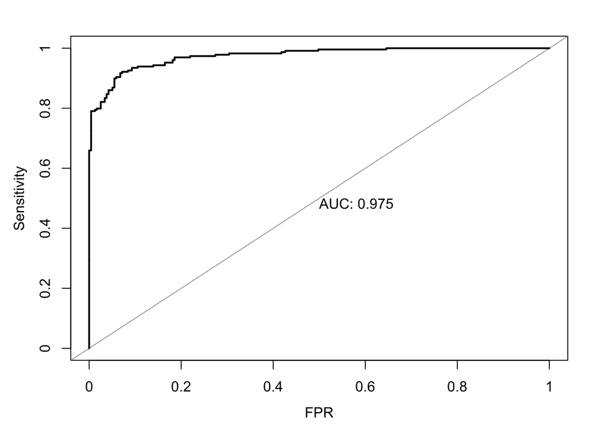

```r
plot(rocBaseStepPlot, asp=NA, legacy.axes = TRUE, print.auc=TRUE, xlab="FPR")
```

*confusion Matrix.*

```r
# Confusion Matrix of Base Model
baseConfusion = as.factor(as.integer(fitted(base_model) > .5))
baseCM = confusionMatrix(baseConfusion, as.factor(base_model$y), positive = "1")
caretResults = data.frame(Accurarcy = baseCM$overall[['Accuracy']],
                           ClassErrorRate = 1 - baseCM$overall[['Accuracy']],
                           Precision = baseCM$byClass[['Precision']],
                           Senstivity = baseCM$byClass[['Sensitivity']],
                           Specificity = baseCM$byClass[['Specificity']],
                           F1 = baseCM$byClass[['F1']])
# Confusion Matrix of Base Transformation Model
baseTransformConfusion = as.factor(as.integer(fitted(base_transform_model ) > .5))
baseTransformCM = confusionMatrix(baseTransformConfusion, as.factor(base_transform_model$y), positive = "1")
caretTransformResults = data.frame(Accurarcy = baseTransformCM$overall[['Accuracy']],
                           ClassErrorRate = 1 - baseTransformCM$overall[['Accuracy']],
                           Precision = baseTransformCM$byClass[['Precision']],
                           Senstivity = baseTransformCM$byClass[['Sensitivity']],
                           Specificity = baseTransformCM$byClass[['Specificity']],
                           F1 = baseTransformCM$byClass[['F1']])

# Confusion Matrix of Base Backward Elimination Model
baseBackwardConfusion = as.factor(as.integer(fitted(base_backward_model ) > .5))
baseBackwardCM = confusionMatrix(baseBackwardConfusion, as.factor(base_backward_model$y), positive = "1")
caretBackwardResults = data.frame(Accurarcy = baseBackwardCM$overall[['Accuracy']],
                           ClassErrorRate = 1 - baseBackwardCM$overall[['Accuracy']],
                           Precision = baseBackwardCM$byClass[['Precision']],
                           Senstivity = baseBackwardCM$byClass[['Sensitivity']],
                           Specificity = baseBackwardCM$byClass[['Specificity']],
                           F1 = baseBackwardCM$byClass[['F1']])

# Confusion Matrix of Base Step Model
baseStepConfusion = as.factor(as.integer(fitted(base_step_model ) > .5))
baseStepCM = confusionMatrix(baseStepConfusion, as.factor(base_step_model$y), positive = "1")
caretStepResults = data.frame(Accurarcy = baseStepCM$overall[['Accuracy']],
                           ClassErrorRate = 1 - baseStepCM$overall[['Accuracy']],
                           Precision = baseStepCM$byClass[['Precision']],
                           Senstivity = baseStepCM$byClass[['Sensitivity']],
                           Specificity = baseStepCM$byClass[['Specificity']],
                           F1 = baseStepCM$byClass[['F1']])
TotalConMatrix = rbind(caretResults, caretTransformResults, caretBackwardResults, caretStepResults)
knitr::kable(TotalConMatrix)
```

| Accurarcy | ClassErrorRate | Precision | Senstivity | Specificity | F1 |
| --- | --- | --- | --- | --- | --- |
| 0.9248927 | 0.0751073 | 0.9330357 | 0.9126638 | 0.9367089 | 0.9227373 |
| 0.9270386 | 0.0729614 | 0.9333333 | 0.9170306 | 0.9367089 | 0.9251101 |
| 0.9120172 | 0.0879828 | 0.9196429 | 0.8995633 | 0.9240506 | 0.9094923 |
| 0.9248927 | 0.0751073 | 0.9292035 | 0.9170306 | 0.9324895 | 0.9230769 |

After analyzing all our four models, we will be using the Base_Step_Model for our prediction.

Because of the Observations we discussed.

## Evalution

Finally, when we apply the Step model to the evalution data, it predicts there are 21 obs below the median crime rate and 19 above the median crime rate.

```r
eval_results = predict(base_step_model, newdata = test)
table(as.integer(eval_results > .5))
```

```
##
##  0  1
## 21 19
```